# Exercise 2

Greg Merchant

August 1, 2015

# Flights at ABIA

```r
library(reshape2)
library(ggplot2)
library(plyr)
flights = read.csv('../data/ABIA.csv')
names(flights)
```

```
##  [1] "Year"              "Month"             "DayofMonth"
##  [4] "DayOfWeek"         "DepTime"           "CRSDepTime"
##  [7] "ArrTime"           "CRSArrTime"        "UniqueCarrier"
## [10] "FlightNum"         "TailNum"           "ActualElapsedTime"
## [13] "CRSElapsedTime"    "AirTime"           "ArrDelay"
## [16] "DepDelay"          "Origin"            "Dest"
## [19] "Distance"          "TaxiIn"            "TaxiOut"
## [22] "Cancelled"         "CancellationCode"  "Diverted"
## [25] "CarrierDelay"      "WeatherDelay"      "NASDelay"
## [28] "SecurityDelay"     "LateAircraftDelay"
```

```r
dim(flights)
```

```
## [1] 99260    29
```

```r
smaller = flights[-c(10,11,12,13,14,19,20,21,23,24,25,26,27,28,29)]
names(smaller)
```

```
##  [1] "Year"          "Month"         "DayofMonth"    "DayOfWeek"
##  [5] "DepTime"       "CRSDepTime"    "ArrTime"       "CRSArrTime"
##  [9] "UniqueCarrier" "ArrDelay"      "DepDelay"      "Origin"
## [13] "Dest"          "Cancelled"
```

```r
#convert a date object
smaller$depdate = as.Date(paste(smaller$DayofMonth,smaller$Month,smaller$Year,sep="."),"%d.%m.%Y")

GetHour= function(time){
        if (nchar(time) == 4){
                return (substr(time,1,2))
        }
        return (substr(time,1,1))
}

smaller$hour = lapply(smaller$CRSDepTime,GetHour)


totaldelay = rowsum(smaller[c(10,11)],factor(smaller$depdate),na.action=na.pass, na.rm = TRUE)
avgDailyDelay = aggregate (smaller[c(10,11)],list(smaller$depdate),FUN= mean, na.action = na.pass, na.rm = TRUE)
names(avgDailyDelay) = c('D1ay','ArrDelay','DepDelay')
avgDailyDelay_long = melt(avgDailyDelay,id="D1ay")

avgDailyDelay = aggregate(smaller[c(10,11)],list(smaller$depdate),FUN=mean,na.action=na.pass, na.rm= TRUE)

avgMonthlyDelay= aggregate(smaller[c(10,11)],list(smaller$Month),FUN = mean, na.action = na.pass, na.rm = TRUE)



totalMonthlyCancelation = rowsum(smaller[14],factor(smaller$Month), na.action= na.pass, na.rm = TRUE)




names(avgMonthlyDelay) = c('Mon','ArrDelay','DepDelay')
months = c('Jan','Feb','Mar','Apr','May','Jun','Jul','Aug','Sep','Oct','Nov','Dec')
avgMonthlyDelay$Mon = months
totalMonthlyCancelation$Mon = c(1,2,3,4,5,6,7,8,9,10,11,12)





lapply(avgMonthlyDelay,class)
```

```
## $Mon
## [1] "character"
##
## $ArrDelay
## [1] "numeric"
##
## $DepDelay
## [1] "numeric"
```

```r
names(avgDailyDelay_long)
```

```
## [1] "D1ay"     "variable" "value"
```

```r
melted = melt(avgMonthlyDelay,id="Mon")
melted$Mon = factor(melted$Mon, level = months)
melted2 = cbind(melted,totalMonthlyCancelation)
```

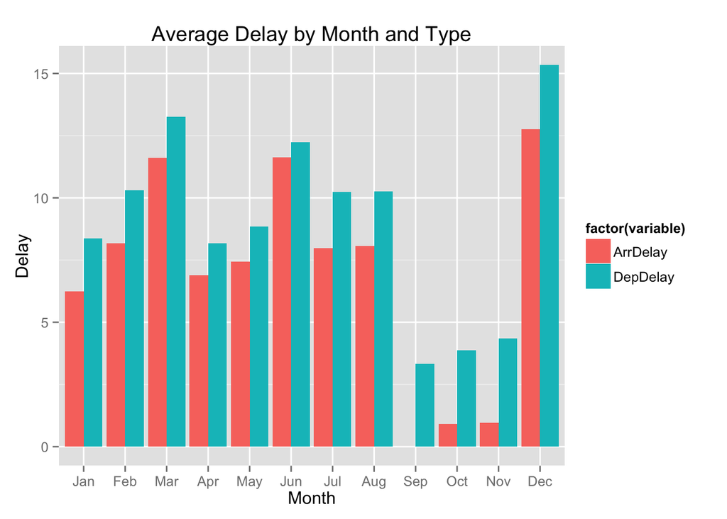

# Author Atribution

```r
library(tm)
library(arules)
```

```r
author_dirs_train = Sys.glob('../data/ReutersC50/C50train/*')
author_dirs_test = Sys.glob('../data/ReutersC50/C50test/*')
author_dirs_train = author_dirs_train[1:50]
author_dirs_test = author_dirs_test[1:50]
file_list_train = NULL
file_list_test = NULL
train_labels = NULL
test_labels = NULL


readerPlain = function(fname){
        readPlain(elem=list(content=readLines(fname)),
                  id=fname, language='en') }

for(author in author_dirs_train) {
    author_name = substring(author, first=29)
    files_to_add = Sys.glob(paste0(author, '/*.txt'))
    file_list_train = append(file_list_train, files_to_add)
    train_labels = append(train_labels, rep(author_name, length(files_to_add)))
}

for(author in author_dirs_test) {
    author_name = substring(author, first=28)
    files_to_add = Sys.glob(paste0(author, '/*.txt'))
    file_list_test = append(file_list_test, files_to_add)
    test_labels = append(test_labels, rep(author_name, length(files_to_add)))
}


#Not sure if I need this yet
uniquenames = unique(train_labels)

#training set up
train_docs = lapply(file_list_train, readerPlain)
names(train_docs) = file_list_train
names(train_docs) = sub('.txt', '', names(train_docs))

train_corpus = Corpus(VectorSource(train_docs))
names(train_corpus) = train_labels

train_corpus = tm_map(train_corpus, content_transformer(tolower)) # make everything lowercase
train_corpus = tm_map(train_corpus, content_transformer(removeNumbers)) # remove numbers
train_corpus = tm_map(train_corpus, content_transformer(removePunctuation)) # remove punctuation
train_corpus = tm_map(train_corpus, content_transformer(stripWhitespace)) ## remove excess white-space
train_corpus = tm_map(train_corpus, content_transformer(removeWords), stopwords("SMART"))

DTM_train = DocumentTermMatrix(train_corpus)

DTM_train = removeSparseTerms(DTM_train, 0.975)

#test set up
test_docs = lapply(file_list_test, readerPlain)
names(test_docs) = file_list_test
names(test_docs) = sub('.txt', '', names(test_docs))

test_corpus = Corpus(VectorSource(test_docs))
names(test_corpus) = test_labels

test_corpus = tm_map(test_corpus, content_transformer(tolower)) # make everything lowercase
test_corpus = tm_map(test_corpus, content_transformer(removeNumbers)) # remove numbers
test_corpus = tm_map(test_corpus, content_transformer(removePunctuation)) # remove punctuation
test_corpus = tm_map(test_corpus, content_transformer(stripWhitespace)) ## remove excess white-space
test_corpus = tm_map(test_corpus, content_transformer(removeWords), stopwords("SMART"))

DTM_test = DocumentTermMatrix(test_corpus)

DTM_test = removeSparseTerms(DTM_test, 0.975)



X_train = as.matrix(DTM_train)
X_test = as.matrix(DTM_test)
#Add authors name to the end


trainnames = colnames(X_train)
testnames = colnames(X_test)

droptestwords = vector(length=0)
for (word in testnames)  {if (!word %in% trainnames) {droptestwords = c(droptestwords,word)}}

zerotrainwords = vector(length=0)
for (word in trainnames)  {if (!word %in% testnames) {zerotrainwords = c(zerotrainwords,word)}}

new_X_test = X_test[,!colnames(X_test) %in% droptestwords]
new_X_train = X_train[,!colnames(X_train) %in% zerotrainwords]

smooth_count = 1/nrow(X_train)

train_smooth = new_X_train + smooth_count
test_smooth = new_X_test + smooth_count

author_matrix = rowsum(train_smooth, train_labels)
author_sum = rowSums(author_matrix)
log_author = log(author_matrix/author_sum)
author_final = log_author[,!colnames(log_author) %in% zerotrainwords]



prediction = author_final %*% t(new_X_test)
pred_trans = t(prediction)



author_prediction = colnames(pred_trans)[max.col(pred_trans)]
author_actual = rownames(pred_trans)

Correct_TF = as.integer(author_prediction == author_actual)
total_correct = sum(Correct_TF)




outcomes = cbind.data.frame(author_actual, author_prediction, Correct_TF)
percent_correct = sum(Correct_TF)/length(Correct_TF)

correct_by_author = aggregate.data.frame(outcomes$Correct_TF, by=list(authors = outcomes$author_actual), FUN = sum)
correct_by_author$percent = correct_by_author$x/50
correct_by_author = as.data.frame(correct_by_author)


ordered = correct_by_author[order(correct_by_author$percent),]
```

After wrangling the data I got Naive Bayes to work. The bottom 5 authors that Naive Bayes struggeled the most to classify were:

```r
head(ordered)
```

```
##             authors  x percent
## 8       DavidLawder  7    0.14
## 4   BenjaminKangLim 11    0.22
## 44      ScottHillis 11    0.22
## 7  DarrenSchuettler 13    0.26
## 13 HeatherScoffield 16    0.32
## 9     EdnaFernandes 18    0.36
```

The top 5 that Niave Bayes best preidcted are listed below with their percentage correct.

```r
tail(ordered)
```

```
##            authors  x percent
## 36       NickLouth 43    0.86
## 6      BradDorfman 46    0.92
## 21     KarlPenhaul 46    0.92
## 11  FumikoFujisaki 49    0.98
## 16    JimGilchrist 49    0.98
## 29 LynnleyBrowning 49    0.98
```

I attempted several- the steps I took for all three were listed below.

I decide to attempt to use boosting becuase it has beena powerful tool in the past- and a good means of getting a baselines. Unfortunately for this type of classification- Boosting did not perform well.

```r
library(adabag)
train_log_matrix = log(train_smooth)
test_log_matrix = log(test_smooth)


trainDF = as.data.frame(train_log_matrix, row.names = file_list_train)
trainDF$labels = factor(train_labels)
testDF = as.data.frame(test_log_matrix, row.names = 1:2500)
testDF$labels = factor(test_labels)
```

```r
train.boosting = boosting(labels ~ . , data=trainDF, mfinal=100, control=rpart.control(maxdepth = 6))

prediction = predict.boosting(train.boosting,newdata=testDF)
```

```r
prediction$confusion
```

```
##                   Observed Class
## Predicted Class    AaronPressman AlanCrosby AlexanderSmith BenjaminKangLim
##   AlanCrosby                   0         23              0               0
##   BenjaminKangLim              0          0              0               5
##   BernardHickey                0          0              0               0
##   DarrenSchuettler             0          0              0               0
##   DavidLawder                  0          0              0               0
##   EricAuchard                  3          0             32               0
##   FumikoFujisaki               0          0              0               1
##   GrahamEarnshaw               0          0              0               0
##   HeatherScoffield             0          0              0               0
##   JanLopatka                   0         14              0               0
##   JimGilchrist                 0          0              0               0
##   JohnMastrini                 0          4              0               0
##   KevinMorrison                0          0              0               0
##   LydiaZajc                    0          0              0               0
##   LynneO'Donnell               0          0              0               2
##   LynnleyBrowning              0          0              0               0
##   MarcelMichelson              0          0              0               0
##   MarkBendeich                 0          0              0               0
##   MartinWolk                  46          9             18               1
##   MureDickie                   1          0              0              38
##   PeterHumphrey                0          0              0               3
##                   Observed Class
## Predicted Class    BernardHickey BradDorfman DarrenSchuettler DavidLawder
##   AlanCrosby                   0           0                0           0
##   BenjaminKangLim              0           0                0           0
##   BernardHickey               11           0                0           0
##   DarrenSchuettler             0           0               15           0
##   DavidLawder                  0           0                0          26
##   EricAuchard                  0           0                0           5
##   FumikoFujisaki               0           0                0           1
##   GrahamEarnshaw               0           0                0           0
##   HeatherScoffield             0           0               30           0
##   JanLopatka                   0           0                0           0
##   JimGilchrist                 0           0                0           0
##   JohnMastrini                 0           0                0           0
##   KevinMorrison               32           0                0           0
##   LydiaZajc                    0           0                1           0
##   LynneO'Donnell               0           0                0           0
```

[output cut: 244 more lines]

```
##   FumikoFujisaki                0          0          0            1
##   GrahamEarnshaw                0          0          0            0
##   HeatherScoffield              0          0          0            0
##   JanLopatka                    0          0          0            0
##   JimGilchrist                  0          0          2            1
##   JohnMastrini                  0          0          0            0
##   KevinMorrison                 0          1          0            0
##   LydiaZajc                     0          0          0            0
##   LynneO'Donnell                0          0          0            1
##   LynnleyBrowning               0          1          0            0
##   MarcelMichelson               0          1          0            0
##   MarkBendeich                  0          0          0            0
##   MartinWolk                   49         18         15            2
##   MureDickie                    0          4          1           37
##   PeterHumphrey                 0          0          0            7
```

```r
table(prediction$class)
```

```
##
##       AlanCrosby  BenjaminKangLim    BernardHickey DarrenSchuettler
##               39               22               21               51
##      DavidLawder      EricAuchard   FumikoFujisaki   GrahamEarnshaw
##               70              311               45               32
## HeatherScoffield       JanLopatka     JimGilchrist     JohnMastrini
##               44               87               56               17
##    KevinMorrison        LydiaZajc   LynneO'Donnell  LynnleyBrowning
##               86               28               47               48
##  MarcelMichelson     MarkBendeich       MartinWolk       MureDickie
##               99               23              939              276
##    PeterHumphrey
##              159
```

```r
test_pred = as.data.frame(prediction$class)
names(test_pred) = 'pred'
test_pred$actual = test_labels
test_pred$check = 0

train_error = 1-sum(train.boosting$class == trainDF$labels) / length(trainDF$labels)
prediction$error
```

```
## [1] 0.7768
```

I believe that Logistic Regression should outperform Naive Bayes becuase Naive Bayes is hampered by it “Niaviety”. Naive Bayes assumes that all items are independent, when in reality there are likely several words that are often paired together that act a stronger predictor than merely single-word frequencies.

```r
trainDF = as.data.frame(new_X_train,row.names = (1:2500))
trainDF$label = train_labels
testDF = as.data.frame(new_X_test, row.names =(1:2500))
testDF$label = test_labels
namedf = as.data.frame(uniquenames)


FactDF = function(author,df) {
        author_train = trainDF
        author_train$Fact_target = 0
        author_train$Fact_target = as.integer(author_train$label == author)
        return (author_train)
}

test = apply(namedf, 1, FactDF, df=trainDF)


mylogit = glm(Fact_target~.-label, data=test[[1]], family=binomial)
```

Ultiamtley I couldn’t get logistic regression to converge. I’m usnure what the exact issue was, but the convergence never occured and thus I was unable to make a prediction.

Next I tried randomForest.

```r
library(randomForest)
set.seed(25)

trainDF2 = trainDF
trainDF2 = trainDF[-c(127)]
testDF2 = testDF[-c(127)]
rf_test = randomForest(factor(label)~.,data=trainDF2,mtry=15,ntree=150)
rf_pred = predict(rf_test, newdata=testDF)
rfDF = as.data.frame(rf_pred)
rfDF$actual = test_labels
rfDF$check = as.numeric(rfDF$actual == rfDF$rf_pred)
sum(rfDF$check)/dim(rfDF)[1]
```

```
## [1] 0.6092
```

```r
correct_by_author2 = aggregate.data.frame(rfDF$check, by=list(authors = rfDF$actual), FUN = sum)

correct_by_author2$percent = correct_by_author2$x/50
correct_by_author2 = as.data.frame(correct_by_author2)

ordered2 = correct_by_author2[order(correct_by_author2$percent),]
head(ordered2)
```

```
##           authors  x percent
## 9   EdnaFernandes  9    0.18
## 3  AlexanderSmith 10    0.20
## 8     DavidLawder 10    0.20
## 14  JaneMacartney 10    0.20
## 50   WilliamKazer 11    0.22
## 44    ScottHillis 13    0.26
```

```r
tail(ordered2)
```

```
##            authors  x percent
## 21     KarlPenhaul 46    0.92
## 33    MatthewBunce 46    0.92
## 40      RobinSidel 46    0.92
## 11  FumikoFujisaki 49    0.98
## 29 LynnleyBrowning 49    0.98
## 16    JimGilchrist 50    1.00
```

So I was able to get a total of 60% accuracy using random Forest with a mtry of 15 and running 150 trees.

# Practice with association rule mining

```r
library(arules)
groceries <- read.transactions("../data/groceries.txt", format='basket',sep=',')
groceryrules = apriori(groceries, parameter=list(support=.01, confidence=.5, maxlen=4))
```

```
##
## Parameter specification:
##  confidence minval smax arem  aval originalSupport support minlen maxlen
##         0.5    0.1    1 none FALSE            TRUE    0.01      1      4
##  target   ext
##   rules FALSE
##
## Algorithmic control:
##  filter tree heap memopt load sort verbose
##     0.1 TRUE TRUE  FALSE TRUE    2    TRUE
##
## apriori - find association rules with the apriori algorithm
## version 4.21 (2004.05.09)        (c) 1996-2004   Christian Borgelt
## set item appearances ...[0 item(s)] done [0.00s].
## set transactions ...[169 item(s), 9835 transaction(s)] done [0.00s].
## sorting and recoding items ... [88 item(s)] done [0.00s].
## creating transaction tree ... done [0.00s].
## checking subsets of size 1 2 3 4 done [0.00s].
## writing ... [15 rule(s)] done [0.00s].
## creating S4 object  ... done [0.00s].
```

```r
inspect(groceryrules)
```

```
##    lhs                     rhs                   support confidence     lift
## 1  {curd,
##     yogurt}             => {whole milk}       0.01006609  0.5823529 2.279125
## 2  {butter,
##     other vegetables}   => {whole milk}       0.01148958  0.5736041 2.244885
## 3  {domestic eggs,
##     other vegetables}   => {whole milk}       0.01230300  0.5525114 2.162336
## 4  {whipped/sour cream,
##     yogurt}             => {whole milk}       0.01087951  0.5245098 2.052747
## 5  {other vegetables,
##     whipped/sour cream} => {whole milk}       0.01464159  0.5070423 1.984385
## 6  {other vegetables,
##     pip fruit}          => {whole milk}       0.01352313  0.5175097 2.025351
## 7  {citrus fruit,
##     root vegetables}    => {other vegetables} 0.01037112  0.5862069 3.029608
## 8  {root vegetables,
##     tropical fruit}     => {other vegetables} 0.01230300  0.5845411 3.020999
## 9  {root vegetables,
##     tropical fruit}     => {whole milk}       0.01199797  0.5700483 2.230969
## 10 {tropical fruit,
##     yogurt}             => {whole milk}       0.01514997  0.5173611 2.024770
## 11 {root vegetables,
##     yogurt}             => {other vegetables} 0.01291307  0.5000000 2.584078
## 12 {root vegetables,
##     yogurt}             => {whole milk}       0.01453991  0.5629921 2.203354
## 13 {rolls/buns,
##     root vegetables}    => {other vegetables} 0.01220132  0.5020921 2.594890
## 14 {rolls/buns,
##     root vegetables}    => {whole milk}       0.01270971  0.5230126 2.046888
## 15 {other vegetables,
##     yogurt}             => {whole milk}       0.02226741  0.5128806 2.007235
```

```r
inspect(subset(groceryrules, subset=lift >3))
```

```
##   lhs                  rhs                   support confidence     lift
## 1 {citrus fruit,
##    root vegetables} => {other vegetables} 0.01037112  0.5862069 3.029608
## 2 {root vegetables,
##    tropical fruit}  => {other vegetables} 0.01230300  0.5845411 3.020999
```

```r
inspect(subset(groceryrules, subset=confidence>.58))
```

```
##   lhs                  rhs                   support confidence     lift
## 1 {curd,
##    yogurt}          => {whole milk}       0.01006609  0.5823529 2.279125
## 2 {citrus fruit,
##    root vegetables} => {other vegetables} 0.01037112  0.5862069 3.029608
## 3 {root vegetables,
##    tropical fruit}  => {other vegetables} 0.01230300  0.5845411 3.020999
```

```r
inspect(subset(groceryrules, subset=support > .011 & confidence > 0.55))
```

```
##   lhs                   rhs                   support confidence     lift
## 1 {butter,
##    other vegetables} => {whole milk}       0.01148958  0.5736041 2.244885
## 2 {domestic eggs,
##    other vegetables} => {whole milk}       0.01230300  0.5525114 2.162336
## 3 {root vegetables,
##    tropical fruit}   => {other vegetables} 0.01230300  0.5845411 3.020999
## 4 {root vegetables,
##    tropical fruit}   => {whole milk}       0.01199797  0.5700483 2.230969
## 5 {root vegetables,
##    yogurt}           => {whole milk}       0.01453991  0.5629921 2.203354
```

I used thresholds of 0.01 for support, 0.5 for confidence, and 4 for maxlen. Ultiatmely I came to theses values after trying various levles.